# Practical 5: Clustering

Nina van Gerwen (1860852)

2022-12-15

## 1: Introduction

```r
library(MASS)
library(tidyverse)
library(patchwork)
```

```r
library(ggdendro)
```

### 1.1: Commenting data simulation code

```r
## To simulate data, we do the following

## First, set a seed for reproducibility
set.seed(123)

## Create a 2 by 2 variance-covariance matrix
sigma      <- matrix(c(1, .5, .5, 1), 2, 2)

## Create a matrix with data that is simulated from a
## multivariate normal distribution that has:

  ## 2 variables, both with a mean of 5 and variance-covariance stated in sigma
  ## 100 observations
sim_matrix <- mvrnorm(n = 100, mu = c(5, 5),
                      Sigma = sigma)

## Name the columns from the simulated matrix x1 and x2
colnames(sim_matrix) <- c("x1", "x2")

## Create a tibble of the simulated matrix that has another
## variable which denotes one of three classes (A, B, C)
## which are randomly sampled with equal probabilities for every observation
sim_df <-
  sim_matrix %>%
  as_tibble() %>%
  mutate(class = sample(c("A", "B", "C"), size = 100,
                        replace = TRUE))

## Create another tibble from the earlier created tibble that
## changes the variables in the following way:
sim_df_small <-
  sim_df %>%
                        ## if class is A, x2 becomes x2 + .5
  mutate(x2 = case_when(class == "A" ~ x2 + .5,
                        ## if class is B, x2 becomes x2 - .5
                        class == "B" ~ x2 - .5,
                        ## and so on
                        class == "C" ~ x2 + .5),
         ## do similar changes for x1
         x1 = case_when(class == "A" ~ x1 - .5,
                        class == "B" ~ x1 - 0,
                        class == "C" ~ x1 + .5))

## Repeat the process from the previous created tibble, but now increase
## the values by which x2 and x1 change depending on class
sim_df_large <-
  sim_df %>%
  mutate(x2 = case_when(class == "A" ~ x2 + 2.5,
                        class == "B" ~ x2 - 2.5,
                        class == "C" ~ x2 + 2.5),
         x1 = case_when(class == "A" ~ x1 - 2.5,
                        class == "B" ~ x1 - 0,
                        class == "C" ~ x1 + 2.5))
```

### 1.2: Creating two unsupervised datasets

To do this, we simply remove the class features.

```r
sim_df_small <- sim_df_small %>% select(-class)

sim_df_large <- sim_df_large %>% select(-class)
```

### 1.3: Creating scatterplots

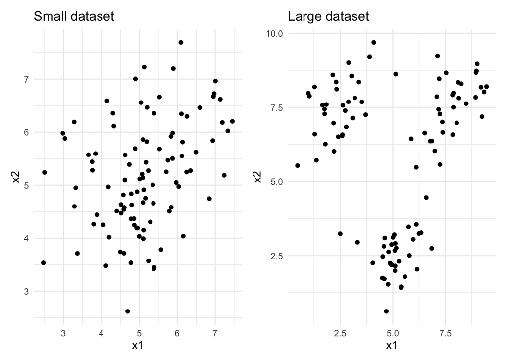

```r
plot_one <- sim_df_small %>% ggplot(., aes(x = x1, y = x2)) +
  geom_point() + theme_minimal() + labs(title = "Small dataset")
plot_two <- sim_df_large %>% ggplot(., aes(x = x1, y = x2)) +
  geom_point() + theme_minimal() + labs(title = "Large dataset")

plot_one + plot_two + plot_layout(ncol = 2, nrow = 1)
```

Looking at the plots, we find that the clusters in the sim_df_large dataset are more defined. This is because the differences we defined through case_when() were bigger there compared to the sim_df_small dataset.

## 2: Hierarchical clustering

### 2.4: Running a hierarchical clustering on both datasets and plotting the dendograms

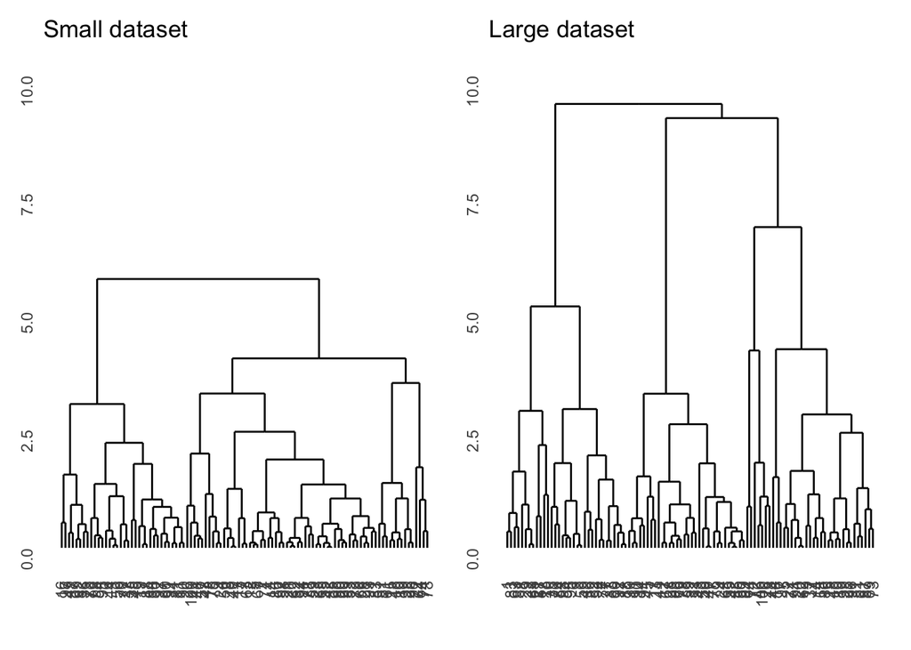

```r
distance_small <- dist(sim_df_small, method = "euclidean")
results_small <- hclust(distance_small, method = "complete")

distance_large <- dist(sim_df_large, method = "euclidean")
results_large <- hclust(distance_large, method = "complete")

small_dendo <- ggdendrogram(results_small) + ylim(0, 10) +
  labs(title = "Small dataset")
large_dendo <- ggdendrogram(results_large) + ylim(0, 10) +
  labs(title = "Large dataset")
small_dendo + large_dendo + plot_layout(ncol = 2)
```

Looking at the difference between the dendrograms, we find that mostly the scale is different. The large dataset has higher values on the y-axis. The y-axis represents how similar observations are in euclidean distance. Therefore, this result is to be expected as the differences between the clusters are also larger in the ‘large’ dataset.

### 2.5: Running a manhatten distance hierarchical clustering on small dataset

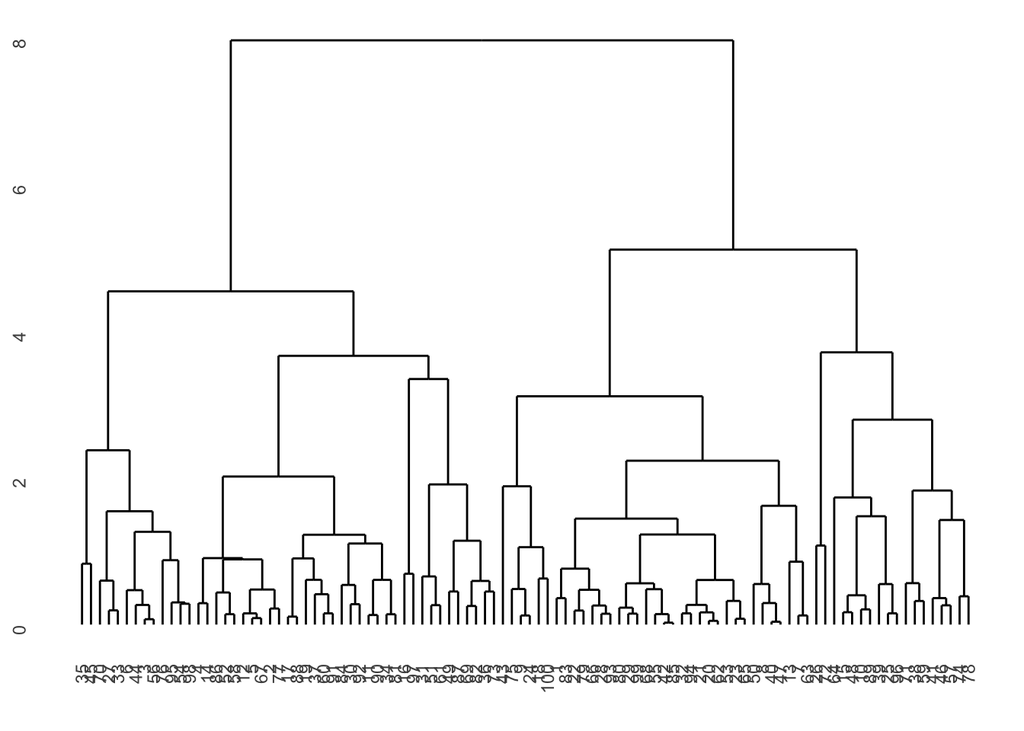

```r
manhatten_distances <- dist(sim_df_small, method = "manhattan")
results_manhat <- hclust(manhatten_distances, method = "complete")

ggdendrogram(results_manhat)
```

### 2.6: Obtaining cluster assignments for the three hierarchical clusters

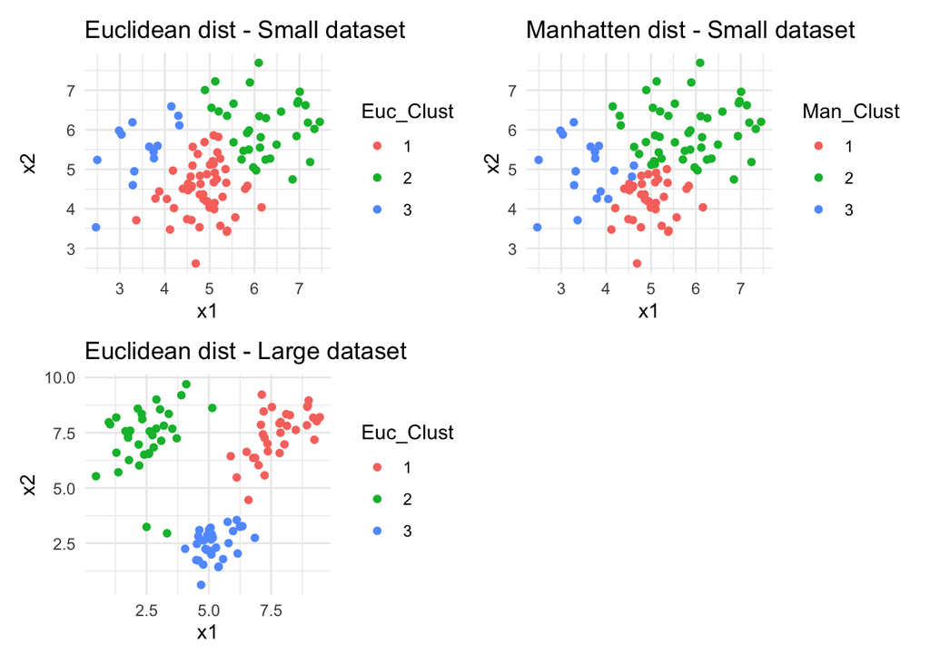

```r
sim_df_small <- sim_df_small %>%
  mutate(Euc_Clust = as.factor(cutree(results_small, k = 3)),
         Man_Clust = as.factor(cutree(results_manhat, k = 3)))

sim_df_large <- sim_df_large %>%
  mutate(Euc_Clust = as.factor(cutree(results_large, k = 3)))

clust_1 <- ggplot(sim_df_small, aes(x = x1, y = x2, col = Euc_Clust)) +
  geom_point() + theme_minimal() + labs(title = "Euclidean dist - Small dataset")

clust_2 <- ggplot(sim_df_small, aes(x = x1, y = x2, col = Man_Clust)) +
  geom_point() + theme_minimal() + labs(title = "Manhatten dist - Small dataset")

clust_3 <- ggplot(sim_df_large, aes(x = x1, y = x2, col = Euc_Clust)) +
  geom_point() + theme_minimal() + labs(title = "Euclidean dist - Large dataset")

clust_1 + clust_2 + clust_3 + plot_layout(ncol = 2, nrow = 2)
```

Looking at the three scatterplots (I was feeling enthousiastic so I am comparing all three), we find that all hierarchical clustering methods worked quite well. I would argue that on the large dataset, two values are wrongly classified (the ones that are green near the blue). Besides that, performance seems similar.

## 3: K-means clustering

### 3.7: Creating K-means clustering with differing amount of K

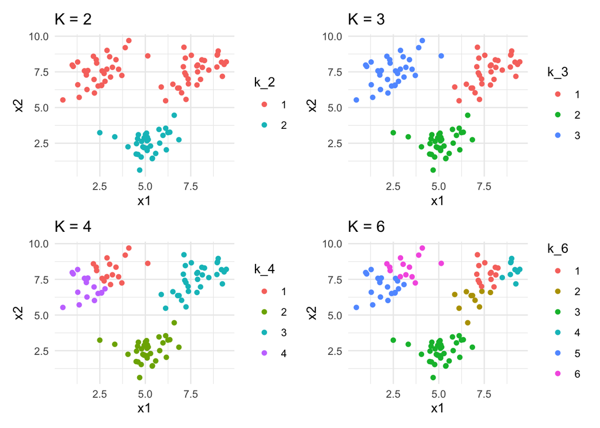

```r
k_2 <- kmeans(sim_df_large, centers = 2)

k_3 <- kmeans(sim_df_large, centers = 3)

k_4 <- kmeans(sim_df_large, centers = 4)

k_6 <- kmeans(sim_df_large, centers = 6)

plot1 <- sim_df_large %>%
  cbind(., k_2 = as.factor(k_2$cluster)) %>%
  ggplot(., aes(x = x1, y = x2, col = k_2)) +
  geom_point() + theme_minimal() + labs(title = "K = 2")

plot2 <- sim_df_large %>%
  cbind(., k_3 = as.factor(k_3$cluster)) %>%
  ggplot(., aes(x = x1, y = x2, col = k_3)) +
  geom_point() + theme_minimal() + labs(title = "K = 3")

plot3 <- sim_df_large %>%
  cbind(., k_4 = as.factor(k_4$cluster)) %>%
  ggplot(., aes(x = x1, y = x2, col = k_4)) +
  geom_point() + theme_minimal() + labs(title = "K = 4")

plot4 <- sim_df_large %>%
  cbind(., k_6 = as.factor(k_6$cluster)) %>%
  ggplot(., aes(x = x1, y = x2, col = k_6)) +
  geom_point() + theme_minimal() + labs(title = "K = 6")

plot1 + plot2 + plot3 + plot4 + plot_layout(ncol = 2, nrow = 2)
```

### 3.8: Repeating the k-means clustering

I did not do it again, but I can theorize that the results will be different. This is because k-means clustering is a random process due to the fact that it assigns all observations to *k* random groups in the beginning.

### 3.9: Performing bootstrap stability assessment for k = 3 and k = 6

```r
library(bootcluster)
k.select(sim_df_large[, 1:2], range = c(3, 6), B = 100, r = 10)
```

```
## $profile
##         3         6
## 0.9717006 0.3924505
##
## $k
## [1] 3
```

Performing k-means clustering whilst also estimating bootstrapping stability, we find that on the ‘large’ dataset, *k = 3* has the highest stability with .972, whereas *k = 6* has a stability of .392. It seems that k-means clustering works pretty well on the dataset, as there initially were 3 clusters!

## 4: Challenge question

### 4.10: Creating a function to perform k-medians clustering

```r
kmedians <- function(dataset, k){
  ## Require tidyverse for the function to work
  require(tidyverse)

  ## Save the number of rows and columns in the dataset
  n <- nrow(dataset)
  c <- ncol(dataset)

  ## Then, we randomly assign the examples to K clusters
  dataset$cluster <- sample(1:k, size = n, replace = TRUE)

  ## Now, we will start a while loop, but first we do a few things
    ## we set a new variable 'change' to TRUE
  change <- TRUE
    ## we copy the dataset twice into temp_data and second_data
  temp_data <- dataset
  second_data <- dataset
    ## we keep a count of the number of iterations
  num <- 0

  ## Then, a while statement that runs as long as 'change' == TRUE
  while(change == TRUE){

    ## First, calculate the centroid for every feature per k and save these
    medians <- temp_data %>%
      group_by(cluster) %>%
      summarize_all(median)

    ## Then, with these centroid values:
    distances <- medians[, 2:(c+1)] %>%
      ## Rowbind them to the temp_data set and remove the cluster variable
      rbind(., select(temp_data, -cluster)) %>%
      ## Calculate the euclidean distances of this new data frame
      dist(., method = "euclidean") %>%
      ## Turn it into a matrix
      as.matrix(.) %>%
      ## And subset the distances for every observation from the initial
      ## dataset to the earlier calculated centroids
      .[(k+1):(n+k), 1:k]

    ## And create an empty vector of future column numbers for every observation
    col_num <- rep(NA, n)

    ## Then start a for loop for 1 to all n observations in which:
    for(i in 1:n){

      ## We first get the ith row of the distance matrix
    temp_dist <- distances[i ,]
      ## We obtain the minimum value of this vector
    min_value <- min(temp_dist)
          ## Now, however, we need to know which column this minimum
          ## value is in, and for this we use a for loop for j to the number of
          ## clusters
        for(j in 1:k){

          ## We make a temporary value that is the jth element of the
          ## ith row of the distance matrix
          temp_value <- temp_dist[j]
            ## And then we check if the temporary value is the minimum value
          if(temp_value == min_value){
            ## If this is the case, the ith col number will be the part of the
            ## jth cluster
            col_num[i] <- j
            ## Else, keep running the for-loop till u find the proper value
          }
        }

    }

    ## After these two for loops, we now have a vector that tells us
    ## for every observation, which cluster centroid is closest
    ## and we set the temp_data cluster variable this vector
    temp_data$cluster <- col_num

    ## Then, we check through an all statement if the temporary data
    ## and the second_data are equal
    change <- ifelse(all(temp_data$cluster == second_data$cluster), FALSE, TRUE)
      ## If they are, it means that none of the assigments changed
      ## and therefore change will change to FALSE and the while loop will stop
    ## If they are not, change stays TRUE and the while loop continues...

    ## Where first, we update the second data to the temporary data
    second_data <- temp_data

    ## And add a 1 to the iteration count
    num <- num + 1

  }

  ## The final output should be the cluster vector after the cluster
  ## assignments have not changed
  output <- temp_data$cluster

  ## We also state that we want the algorithm to print the number of iterations
  print(paste("The algorithm ran", num, "iterations."), quote = FALSE)

  ## Return the final output
  return(output)
}

## To test: we set a seed, and use the kmedians function on the sim_df_large set
set.seed(1248)
clusts <- kmedians(sim_df_large[, 1:2], k = 3)
```

```
## [1] The algorithm ran 4 iterations.
```

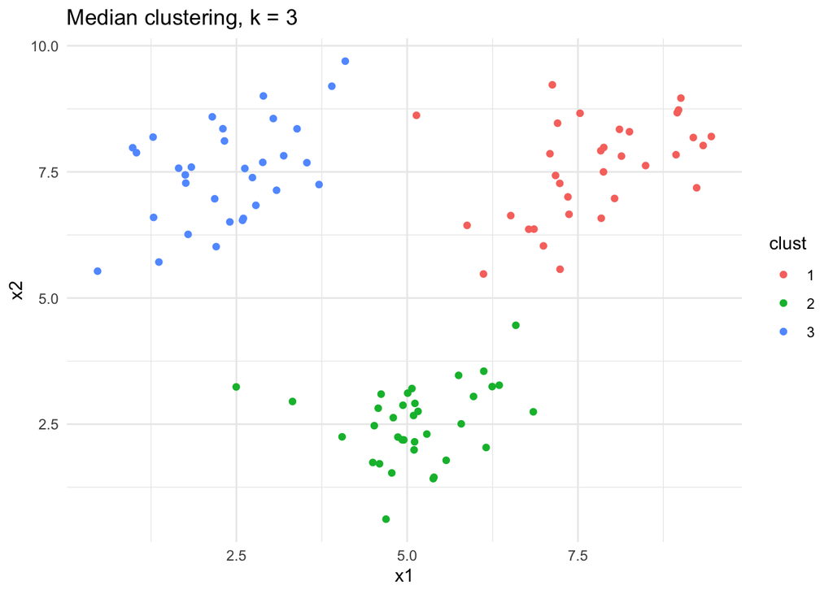

```r
## And we plot it
cbind(sim_df_large, clust = as.factor(clusts)) %>%
  ggplot(., aes(x = x1, y = x2, col = clust)) + geom_point() +
  theme_minimal() + labs(title = "Median clustering, k = 3")
```

Eureka! It works. Only when *k* becomes very large, the algorithm starts to fail. Unsure as to why. Luckily, we will now fix that by making it smart!

### 4.11: Updating the function to be smart

```r
smart_kmedians <- function(dataset, k, smart_init = FALSE){
  require(tidyverse)

  n <- nrow(dataset)
  c <- ncol(dataset)

  ## Everything in this function is the same except for a new argument
  ## and the following if() statement that states that:
      ## if smart_init argument equals TRUE:
  if(smart_init == TRUE){
      ## The initial clusters should be based on hierarchical clustering with
      ## k clusters
  dataset$cluster <- dist(dataset, method = "euclidean") %>%
    hclust(.,  method = "complete") %>%
    cutree(., k = k)
  } else {
    ## Else, all stays the same as before
  dataset$cluster <- sample(1:k, size = n, replace = TRUE)
  }

  change <- TRUE
  temp_data <- dataset
  second_data <- dataset

  num <- 0

  while(change == TRUE){

    medians <- temp_data %>%
      group_by(cluster) %>%
      summarize_all(median)

    distances <- medians[, 2:(c+1)] %>%
      rbind(., select(temp_data, -cluster)) %>%
      dist(., method = "euclidean") %>%
      as.matrix(.) %>%
      .[(k+1):(n+k), 1:k]

    col_num <- rep(NA, n)

    for(i in 1:n){

    temp_dist <- distances[i ,]

    min_value <- min(temp_dist)

        for(j in 1:k){

          temp_value <- temp_dist[j]

          if(temp_value == min_value){
            col_num[i] <- j
          }
        }

    }

    temp_data$cluster <- col_num

    change <- ifelse(all(temp_data$cluster == second_data$cluster), FALSE, TRUE)

    second_data <- temp_data

    num <- num + 1
  }

  output <- temp_data$cluster

  print(paste("The algorithm ran", num, "iterations."), quote = FALSE)

  return(output)
}

set.seed(1248)

kmedians(sim_df_large[, 1:2], k = 3)
```

```
## [1] The algorithm ran 4 iterations.
```

```
##   [1] 1 1 1 3 3 1 2 1 2 3 2 2 2 3 3 3 1 1 3 3 1 3 1 2 3 3 1 2 1 2 3 2 1 2 1 1 3
##  [38] 2 3 2 2 2 2 1 2 3 2 3 1 2 3 1 2 1 2 1 1 3 2 1 3 3 1 2 1 2 2 2 3 2 3 3 3 2
##  [75] 2 1 1 3 2 2 1 1 1 1 2 3 3 1 3 2 2 1 2 3 1 3 3 1 2 3
```

```r
smart_kmedians(sim_df_large[, 1:2], k = 3, smart_init = TRUE)
```

```
## [1] The algorithm ran 3 iterations.
```

```
##   [1] 1 1 1 2 2 1 3 1 3 2 3 3 3 2 2 2 1 1 2 2 1 2 1 3 2 2 1 3 1 3 2 3 1 3 1 1 2
##  [38] 3 2 3 3 3 3 1 3 2 3 2 1 3 2 1 3 1 3 1 1 2 3 1 2 2 1 3 1 3 3 3 2 3 2 2 2 3
##  [75] 3 1 1 2 3 3 1 1 1 1 3 2 2 1 2 3 3 1 3 2 1 2 2 1 3 2
```

Now, as long as smart_init is true, the function also works for large *k*’s and it will overall run fewer iterations of the while loop.